# Hands-on Exercise 9b: Visualising Geospatial Point Data

Author

Htet Kay Khaing

Published

June 16, 2026

Modified

June 17, 2026

## 9.1 Overview

Proportional symbol maps (also known as graduate symbol maps) are a class of maps that use the visual variable of size to represent differences in the magnitude of a discrete, abruptly changing phenomenon, e.g. counts of people. Like choropleth maps, we can create classed or unclassed versions of these maps. The classed ones are known as range-graded or graduated symbols, and the unclassed are called proportional symbols, where the area of the symbols are proportional to the values of the attribute being mapped. In this chapter, we will create a proportional symbol map showing the number of wins by Singapore Pools’ outlets using an R package called **tmap**.

### 9.1.1 Learning outcome

By the end of this chapter, you will acquire the following skills by using appropriate R packages:

- To import an aspatial data file into R.
- To convert it into simple point feature data frame and at the same time, to assign an appropriate projection reference to the newly create simple point feature data frame.
- To plot interactive proportional symbol maps.

## 9.2 Getting Started

Before we get started, we need to ensure that tmap package of R and other related R packages have been installed and loaded into R.

```r
pacman::p_load(sf, tmap, tidyverse)
```

## 9.3 Geospatial Data Wrangling

### 9.3.1 The data

The data set use for this chapter is called *SGPools_svy21*. The data is in csv file format.

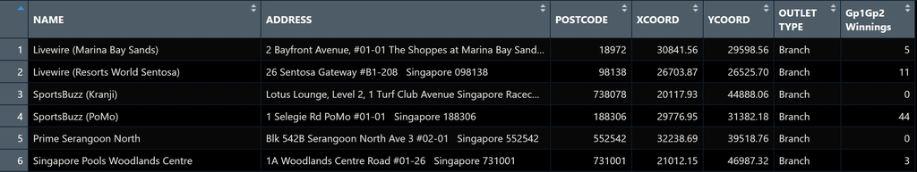

### 9.3.2 Data Import and Preparation

The code chunk below uses *read_csv()* function of **readr** package to import *SGPools_svy21.csv* into R as a tibble data frame called *sgpools*.

```r
sgpools <- read_csv("data/SGPools_svy21.csv")
```

After importing the data file into R, it is important for us to examine if the data file has been imported correctly.

The code chunk below shows list() is used to do the job.

```r
list(sgpools)
```

```
[[1]]
# A tibble: 306 × 7
   NAME           ADDRESS POSTCODE XCOORD YCOORD `OUTLET TYPE` `Gp1Gp2 Winnings`
   <chr>          <chr>      <dbl>  <dbl>  <dbl> <chr>                     <dbl>
 1 Livewire (Mar… 2 Bayf…    18972 30842. 29599. Branch                        5
 2 Livewire (Res… 26 Sen…    98138 26704. 26526. Branch                       11
 3 SportsBuzz (K… Lotus …   738078 20118. 44888. Branch                        0
 4 SportsBuzz (P… 1 Sele…   188306 29777. 31382. Branch                       44
 5 Prime Serango… Blk 54…   552542 32239. 39519. Branch                        0
 6 Singapore Poo… 1A Woo…   731001 21012. 46987. Branch                        3
 7 Singapore Poo… Blk 64…   370064 33990. 34356. Branch                       17
 8 Singapore Poo… Blk 88…   370088 33847. 33976. Branch                       16
 9 Singapore Poo… Blk 30…   540308 33910. 41275. Branch                       21
10 Singapore Poo… Blk 20…   560202 29246. 38943. Branch                       25
# ℹ 296 more rows
```

Notice that the *sgpools* data in tibble data frame and not the common R data frame.

### 9.3.3 Creating a sf data frame from an aspatial data frame

The code chunk below converts sgpools data frame into a simple feature data frame by using *st_as_sf()* of **sf** packages

```r
sgpools_sf <- st_as_sf(sgpools,
                       coords = c("XCOORD", "YCOORD"),
                       crs= 3414)
```

Things to learn from the arguments above:

- The *coords* argument requires to provide the column name of the x-coordinates first then followed by the column name of the y-coordinates.
- The *crs* argument requires to provide the coordinates system in epsg format. [EPSG: 3414](https://epsg.io/3414) is Singapore SVY21 Projected Coordinate System. You can search for other country’s epsg code by referring to [epsg.io](https://epsg.io/).

We can display the basic information of the newly created sgpools_sf by using the code chunk below.

```r
list(sgpools_sf)
```

```
[[1]]
Simple feature collection with 306 features and 5 fields
Geometry type: POINT
Dimension:     XY
Bounding box:  xmin: 7844.194 ymin: 26525.7 xmax: 45176.57 ymax: 47987.13
Projected CRS: SVY21 / Singapore TM
# A tibble: 306 × 6
   NAME                         ADDRESS POSTCODE `OUTLET TYPE` `Gp1Gp2 Winnings`
 * <chr>                        <chr>      <dbl> <chr>                     <dbl>
 1 Livewire (Marina Bay Sands)  2 Bayf…    18972 Branch                        5
 2 Livewire (Resorts World Sen… 26 Sen…    98138 Branch                       11
 3 SportsBuzz (Kranji)          Lotus …   738078 Branch                        0
 4 SportsBuzz (PoMo)            1 Sele…   188306 Branch                       44
 5 Prime Serangoon North        Blk 54…   552542 Branch                        0
 6 Singapore Pools Woodlands C… 1A Woo…   731001 Branch                        3
 7 Singapore Pools 64 Circuit … Blk 64…   370064 Branch                       17
 8 Singapore Pools 88 Circuit … Blk 88…   370088 Branch                       16
 9 Singapore Pools Anchorvale … Blk 30…   540308 Branch                       21
10 Singapore Pools Ang Mo Kio … Blk 20…   560202 Branch                       25
# ℹ 296 more rows
# ℹ 1 more variable: geometry <POINT [m]>
```

The output shows that sgppols_sf is in point feature class. It’s epsg ID is 3414. The bbox provides information of the extend of the geospatial data.

## 9.4 Drawing Proportional Symbol Map

To create an interactive proportional symbol map in R, the view mode of tmap will be used.

The code chunk below will turn on the interactive mode of tmap.

```r
tmap_mode("view")
```

### 9.4.1 It all started with an interactive point symbol map

The code chunks below are used to create an interactive point symbol map.

```r
tm_shape(sgpools_sf) +
  tm_bubbles(fill = "red",
           size = 1,
           col = "black",
           lwd = 1)
```

[interactive chart not shown]

### 9.4.2 Lets make it proportional

To draw a proportional symbol map, we need to assign a numerical variable to the size visual attribute. The code chunks below show that the variable *Gp1Gp2Winnings* is assigned to size visual attribute.

```r
tm_shape(sgpools_sf) +
  tm_bubbles(fill = "red",
             size = "Gp1Gp2 Winnings",
             col = "black",
             lwd = 1)
```

[interactive chart not shown]

### 9.4.3 Lets give it a different colour

The proportional symbol map can be further improved by using the colour visual attribute. In the code chunks below, *OUTLET_TYPE* variable is used as the colour attribute variable.

```r
tm_shape(sgpools_sf) +
  tm_bubbles(fill = "OUTLET TYPE",
             size = "Gp1Gp2 Winnings",
             col = "black",
             lwd = 1)
```

[interactive chart not shown]

### 9.4.4 Faceted plots using tm_facets() method

An impressive and little-know feature of **tmap**’s view mode is that it also works with faceted plots. The argument *sync* in *tm_facets()* can be used in this case to produce multiple maps with synchronised zoom and pan settings.

```r
tm_shape(sgpools_sf) +
  tm_bubbles(fill = "OUTLET TYPE",
             size = "Gp1Gp2 Winnings",
             col = "black",
             lwd = 1) +
  tm_facets(by= "OUTLET TYPE",
            nrow = 1,
            sync = TRUE)
```

[interactive chart not shown]

Finally, we will switch tmap’s Viewer back to plot mode by using the code below.

```r
tmap_mode("plot")
```

## 9.5 Reference

### 9.5.1 All about tmap package

- [tmap: Thematic Maps in R](https://www.jstatsoft.org/article/view/v084i06)
- [tmap](https://cran.r-project.org/web/packages/tmap/index.html)
- [tmap: get started!](https://cran.r-project.org/web/packages/tmap/vignettes/tmap-getstarted.html)
- [tmap: changes in version 2.0](https://cran.r-project.org/web/packages/tmap/vignettes/tmap-changes-v2.html)
- [tmap: creating thematic maps in a flexible way (useR!2015)](http://von-tijn.nl/tijn/research/presentations/tmap_user2015.pdf)
- [Exploring and presenting maps with tmap (useR!2017)](http://von-tijn.nl/tijn/research/presentations/tmap_user2017.pdf)

### 9.5.2 Geospatial data wrangling

- [sf: Simple Features for R](https://cran.r-project.org/web/packages/sf/index.html)
- [Simple Features for R: StandardizedSupport for Spatial Vector Data](https://journal.r-project.org/archive/2018/RJ-2018-009/RJ-2018-009.pdf)
- [Reading, Writing and Converting Simple Features](https://cran.r-project.org/web/packages/sf/vignettes/sf2.html)

### 9.5.3 Data wrangling

- [dplyr](https://dplyr.tidyverse.org/)
- [Tidy data](https://cran.r-project.org/web/packages/tidyr/vignettes/tidy-data.html)
- [tidyr: Easily Tidy Data with ‘spread()’ and ‘gather()’ Functions](https://cran.r-project.org/web/packages/tidyr/tidyr.pdf)